# ANALISI GEOSTATISTICA DEI DATI AMBIENTALI – Livello base (T28_25_3_1)

Francesco Pirotti

2025-09-30

## Riferimenti utili

CRS - coordinate reference system  
https://r.geocompx.org/spatial-class#crs-intro  
https://r-spatial.org/book/02-Spaces.html#sec-crs  
meuse dataset  
https://cloud.r-project.org/web/packages/gstat/vignettes/gstat.pdf  
metodi di interpolazione geografica  
https://r-spatial.org/book/12-Interpolation.html

Applied Spatial Data Analysis with R https://gis.humboldt.edu/OLM/r/Spatial%20Analysis%20With%20R.pdf

## Obiettivo

Stimare i valori di una variabile nel dominio dello spazio (eventualmente anche del tempo)

Cosa si intende per variabilità spaziale?

- Lo stesso fenomeno ha valori diversi se misurato in punti diversi
- Le differenze quasi mai sono puramente casuali: esiste una **dipendenza spaziale** (o autocorrelazione)
- I valori dei punti vicini tendono a somigliarsi di più rispetto a punti lontani → questo è ciò che la geostatistica quantifica.

## Dati di esempio

Useremo il dataset “meuse” e le librerie che vedete sotto

```r
library(tidyverse)
library(stats)
library(ggplot2)
library(terra)
library(gstat)
library(kableExtra)
library(sp)
data(meuse)
class(meuse)

kable(head(meuse, 5), caption = "Dataset *meuse*") %>%
  kable_styling(full_width = FALSE, bootstrap_options = c("striped", "hover"))
```

## Cosa facciamo

Vogliamo un modello per “spiegare” la variabilità e dunque poter stimare (interpolare) al meglio dove non abbiamo informazioni.

Stimare valori di una variabile applicando un modello creato conoscendo valori misurati (e.g. campionamenti). E’ ragionevole adottare un criterio spaziale, ovvero usare un criterio di spazio (il valore del punto sarà probabilmente più simile ad una misura vicina che una misura più lontana, **a parità di altre condizioni)**. Da qui la geostatistica.

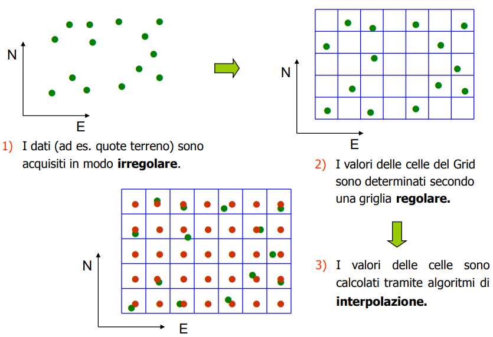

fonte: Appunti GIS Prof. Alberto Guarnieri - CIRGEO

# Giorno 1

## Contenuti

- Richiamo concetti statistici fondamentali: varianza, covarianza, correlazione, autocorrelazione
- Richiamo concetti base su sistemi di riferimento coordinate (CRS), geografiche e proiettate
- Fondamenti statistici dell’analisi spaziale dati e variabili regionalizzate
- Metodi deterministici di stima per interpolazione spaziale (IWD)

## Varianza

Vediamo come valutare alcuni momenti di una distribuzione - media e varianza ci danno il primo e secondo momento. Z è la variabile aleatoria, nel caso del dataset MEUSE possiamo scegliere la concentrazione di Zinco.

$$M(Z)=\mu_Z=\mathbb E[Z]$$

$$M(Z)=\mu_Z=\frac{1}{n}\sum_{j=1}^n{Z_j}$$

$$Var(Z)=\sigma^2_Z=\mathbb{E}\Big[\big(Z-\mathbb{E}[Z]\big)^2\Big].$$

$$Var(Z)=\sigma^2_Z=\frac{\sum_{j=1}^n(Z_j-M_Z)^2}{n}$$

Formula più pratica

$$Var(Z)=\sigma^2_Z=\mathbb{E}[Z^2]-\mathbb{E}[Z]^2$$

$$Var(Z)=\sigma^2_Z=M(Z^2)-M(Z)^2$$

## Varianza esempio

Calcoliamo la varianza con tre formule diverse:

```r
MZ<-mean(meuse$zinc)
VarZ <- var(meuse$zinc)
## media quadratica dei quadrati
MZ2<-mean(meuse$zinc^2)
VarZ <- MZ2 - MZ^2
VarZ <- mean((meuse$zinc-MZ)^2)



plot( meuse$y, meuse$zinc, xlab="Coord Y", ylab="Zinco", pch="+")
abline(a = MZ,0 )
rect(min(meuse$y), MZ-VarZ^0.5, max(meuse$y),
     MZ+VarZ^0.5, col = "#ff000045", border = "#ffffff00")
# varianza  = (dev std)^2
```

## Varianza esempio (2)

```r
hist(meuse$zinc)
rug(meuse$zinc)
rect(MZ-VarZ^0.5, 10000,
     MZ+VarZ^0.5, 0, col = "#ff000045", border = "#ffffff00")
abline(v=MZ, col="red", lwd=2)
```

## Covarianza

La **covarianza** tra due variabili casuali $Z_1$ e $Z_2$ misura quanto esse tendono a variare insieme. Se positiva variano entrambe nella stessa direzione, se negativa in direzioni opposte.

$$\mathrm{Cov}(Z1,Z2)=\mathbb{E}\Big[\big(Z1-\mathbb{E}[Z1]\big)(Z2-\mathbb{E}[Z2]\big)\Big]$$

## Esempio Covarianza

La covarianza dipende dalle unità di misura delle variabili → non è standardizzata. Per questo si usa spesso la **correlazione**, che normalizza la covarianza tra -1 e 1.

La correlazione = 1 equivale ad una covarianza che ha valore uguale alla varianza.

```r
CovZ<-cov(meuse$zinc, meuse$zinc)

var(meuse$zinc) == CovZ
```

## Covarianza

Analizziamo un gradiente di temperatura simulato

```r
load("oggetti.rda")
plot(lat_seq, temps, type = "l", col = "blue", lwd = 2,
     xlab = "Latitude (°N)", ylab = "Temperature (°C)",
     main = "Gradiente Temperatura: Italia → Danimarca")
points(lat_seq, temps, pch = 16, col = rgb(0,0,1,0.3))
```

La covarianza equivale alla varianza se la calcoliamo confrontandola a se stessa, ma se trasliamo di un dato intervallo (“lag”) e la ricalcoliamo, la covarianza non diventa zero, diminuisce gradualmente….

```r
cov(temps,temps)
cov(temps[2:200],temps[1:199])
cov(temps[3:200],temps[1:198])

## Provate con una variabile senza correlazione
# rand <- runif(200)
# cov(rand,rand)
# cov(rand[2:200],rand[1:199])
# cov(rand[3:200],rand[1:198])
```

Questo è un concetto molto importante da comprendere.

Più aumentiamo la distanza del lag, come è ragionevole pensare per dati spazialmente correlati, più diminuisce il valore di covarianza (si allontana dal valore della varianza == covarianza ).

Se si abbassa per poi rialzarsi, può indicare un pattern ricorrente (provate sostituendo i valori di temps con un valore ciclico come `temps <- sin((1:200)/10)` .

```r
nm <- length(temps)
plot(temps[1:200], temps[1:200], pch="x", cex=0.5, xlab="Temperatura", ylab="Temperatura" )
points(temps[1:199], temps[2:200], pch="x", cex=0.5, col="red" )
points(temps[1:198], temps[3:200], pch="x", cex=0.5, col="green" )
```

Non ci crediamo? Rifacciamolo per un dato casuale con media e varianza uguale a quella del nostro dato:

```r
t.rand <- rnorm(nm, mean = MZ, sd = VarZ^0.5)

plot(t.rand[1:(nm-1)], t.rand[2:nm], pch="x", cex=0.5, xlab="km", ylab="Temperatura" )
cc=1
covs.rand<-list("0"=cov(t.rand, t.rand), "1"=cov(t.rand[1:(nm-1)], t.rand[2:nm] ) )

for(lag in seq(6, 36, 10)){
  covs.rand[[as.character(lag)]] <- cov(t.rand[1:(nm-lag)], t.rand[(lag+1):nm])
  points(t.rand[1:(nm-lag)], t.rand[(lag+1):nm], cex=0.5, pch="x", col=cc )
  cc=cc+1
}



plot(names(covs.rand),  unlist(covs.rand), type="b",
     ylab="Covarianza",
     xlab="lag" )
```

## Correlazione

Relazione lineare tra due variabili, cosiddetta di Pearson. Semplicemente normalizza la covarianza per le deviazioni standard delle due variabili moltiplicate tra loro:

$$-1\le\rho_{Z1Z2}=\frac{Cov(Z1Z2)}{\sqrt{Var(Z1)}\cdot\sqrt{Var(Z2)}}=\frac{\sum_{i=1}^n(Z1-{\mu_{Z1}})(Z2-{\mu_{Z2}})}{\sqrt{\sum_{i=1}^n(y_i-{\mu_{Z1}})^2}\sqrt{\sum_{i=1}^n(y_i-{\mu_{Z2}})^2}}\le+1$$

## Autocorrelazione

L’autocorrelazione misura quanto una variabile è correlata con sé stessa quando viene considerato uno spostamento nel dominio dei valori.

In una sola dimensione — sia essa tempo o spazio (ad esempio nel nostro transetto di temperatura SUD → NORD) — questo spostamento viene detto *lag*, traducibile come sfasamento.

L’analisi dell’autocorrelazione si effettua tramite la funzione CCF (Cross-Correlation Function), che nel caso specifico valuta la correlazione della serie con sé stessa a diversi lag.

acf() in R ti mostra l’autocorrelazione ai vari lag (sfasamenti).

- Lag = 1 → confronta ogni punto con il successivo.
- Lag più grandi → confrontano punti sempre più distanti lungo il transetto.

```r
#ccf(temps, temps, plot = F)
#ccf(temps, temps)

# Autocorrelazione
acf(temps, main = "Autocorrelazione della temperatura")
```

# Sistemi di riferimento

Richiamo concetti base su sistemi di riferimento coordinate (CRS), geografiche e proiettate

## Cosa sono i dati spaziali?

Rappresentare informazioni associate alla loro posizione nello spazio

Due modelli: il modello vettoriale ed il modello raster.

Ogni valore è georiferito, ovvero associato ad un punto in un sistema di riferimento, quindi delle coordinate.

L’accuratezza può variare a seconda dello strumento usato per la misura.

L’accuratezza dipende dalla scala, che determina la tolleranza agli errori.

## Modello vettoriale

I dati vettoriali hanno tre primitive geometriche di base: punti linee e poligoni. La base è sempre il punto con una coordinate, in 2d o 3d.

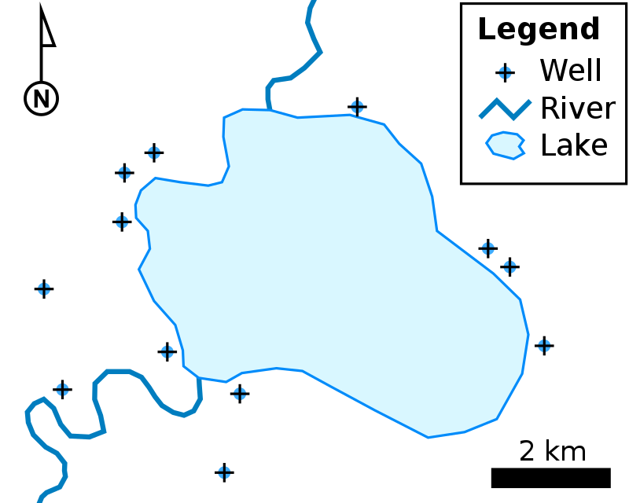

By M. W. Toews - Own work, CC BY-SA 4.0

Ci sono decine di formati digitali per i dati vettoriali.

Per un riferimento vedete la [pagina QUI](https://gdal.org/en/stable/drivers/vector/index.html).

Ad oggi gli strumenti in ambiente R di riferimento per leggere dati vettoriali è la libreria sf.

## Modello raster

Il formato raster è una semplificazione/discretizzazione dello spazio in celle/pixel/ nodi a passo costante, quindi una “griglia” georiferita mediante uno o più punti. Il passo della griglia è spesso identico nelle due direzioni (ma non necessariamente), e ne determina la risoluzione spaziale.

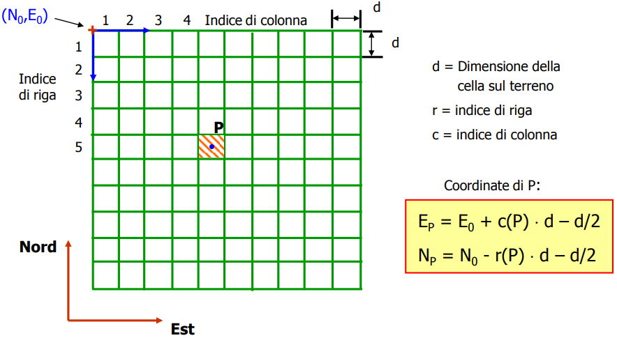

fonte: appunti GIS Prof. Alberto Guarnieri

Può essere 3D (voxel)

Ci sono decine di formati di file che rappresentano dati raster. Per un riferimento vedete la [pagina QUI](https://gdal.org/en/stable/drivers/raster/index.html).

Ad oggi la libreria di riferimento per leggere questi dati è la libreria [terra](https://rspatial.github.io/terra/), e [stars](https://r-spatial.github.io/stars/)

Attenzione alla gestione della memoria in quanto i dati raster possono diventare molto pesanti dal punto di vista di spazio di memoria (1000 pixel x 1000 pixel è un raster “piccolo” ma già fornisce 1e6 elementi.

## Sistemi di riferimento

Sono delle convenzioni - si stabilisce un sistema con una origine ed un orientamento degli assi tra loro perpendicolari - Coordinate planimetriche o polari - Sistemi locali o globali

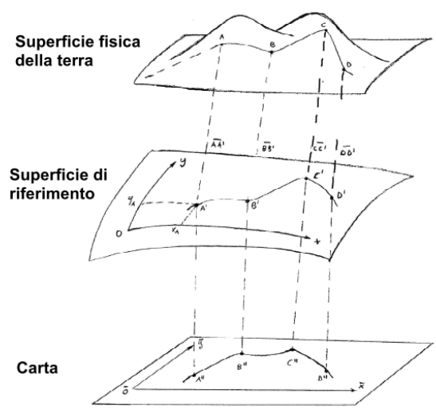

## Sistemi di riferimento - geoide

Prima di tutto bisogna definire un riferimento fisico - la forma della superficie definita come “interfaccia solida” è “complicata” (è elastica e subisce l’effetto di svariate forze che la deformano)… e neanche stabile nel tempo!

Si prende come convenzione la forma che avrebbe la superficie equipotenziale (livello del mare) se non ci fossero terre emerse - lo si chiama GEOIDE. E’ la superficie di riferimento per comprendere dove la gravità spinge l’acqua. NB è in corso con il recente piano di telerilevamento nazionale il calcolo di un nuovo nuovo geoide ufficiale nazionale ([vedi qui](https://rivistageomedia.it/rilievo-e-localizzazione/al-via-la-realizzazione-del-nuovo-modello-altimetrico-del-territorio-italiano))

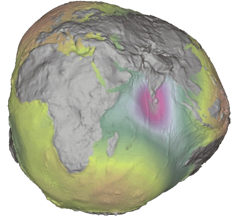

## Sistemi di riferimento - ellissoide

Il geoide è fondamentale per comprendere fenomeni legati alle quote, ma molto complesso da trattare. Si semplifica con **l’ellissoide**, una rappresentazione trattabile matematicamente.

Ci sono tanti ellissoidi che sono stati stimati per avvicinarsi il più possibile alla realtà del geoide

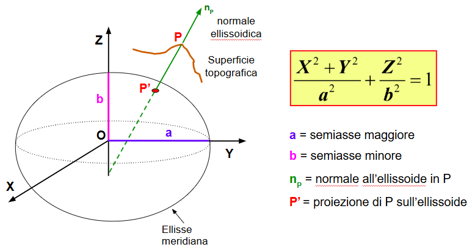

## Coordinate geografiche

Latitudine e longitudine, coordinate polari.

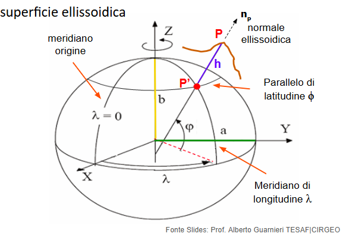

## Coodinate geocentriche

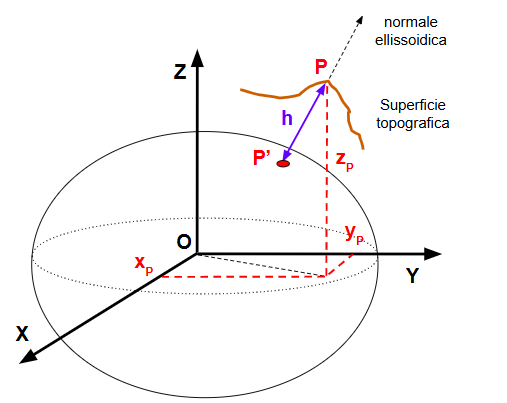

## Coordinate cartografiche

Coordinate planimetriche, su un piano. Ma la terra non è piatta!

**Soluzione**: accettiamo deformazioni ma le teniamo sotto controllo (scala, accuratezza, tolleranza)

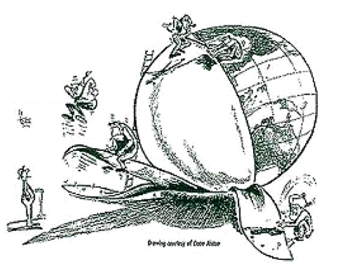

## Coordinate cartografiche

Si proiettano i punti nella “sfera” su un piano.

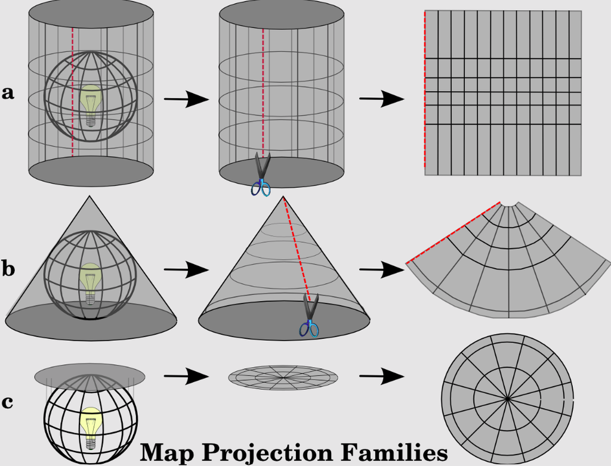

Fonte: QGIS documentation

## I sistemi di riferimento (CRS)

Vedi documentazione di [QGIS QUI](https://docs.qgis.org/3.40/it/docs/gentle_gis_introduction/coordinate_reference_systems.html)

Vedi [NOTA PER IL CORRETTO UTILIZZO DEI SISTEMI GEODETICI](https://www.igmi.org/++theme++igm/pdf/nuova_nota_EPSG.pdf)

## Un esercizio con R

Le coordinate di Prato della Valle: Lat: 45.398557, Long. 11.876460 trasformate nei vari sistemi. **TEST** - prova a consultare il documento IGM e trasformare la coordinata nel sistema “RDN2008 / Zone 12 (N-E)” e vedere come differisce dal sistema “RDN2008 / Italy zone (N-E)” … sono uguali?

```r
library(sf)
lat<-45.398557
long<-11.876460
# punti in classe SF
pt <- st_sfc(st_point(c(long, lat)), crs = 4326)
# UTM fuso 32
pt_utm <- st_transform(pt, 32632)
#
pt_ecef <- st_transform(pt, 4978)
# le coordinate nei vari sistemi
geographic = sf::st_coordinates(pt)
planimetric = st_coordinates(pt_utm)
geocentric = st_coordinates(pt_ecef)
```

## Fondamenti statistici

Fondamenti statistici dell’analisi spaziale dati e variabili regionalizzate

## Variabili regionalizzate

variabili misurate in punti e correlate spazialmente

- Possono essere trattate come campioni di un fenomeno continuo (non discreto)
- Presentano autocorrelazione spaziale

## Statistica descrittiva di base

Vedi slides iniziali

- Media, mediana, varianza, deviazione standard
- Distribuzione dei dati (istogrammi, boxplot)
- Identificazione di outlier - per il trattamento rigoroso delle osservazioni (non lo trattiamo)
- Differenze tra dati indipendenti e dati spazialmente correlati

## Metodi deterministici vs stocastici

I metodi deterministici non considerano la componente aleatoria (incerta, casuale) dei dati, ma si basano su assunzioni deterministiche per stimare i valori in punti non campionati - ovvero **non considerano la struttura spaziale, nessuna autocorrelazione e non forniscono incertezza**.

Stimano il valore Z* in un punto dove non abbiamo una misura usando le misure note vicine, ma come?

$$Z* = F(x,y) = \sum_{i=2}^n w_i
Z_i$$
dove il peso del punto $1$ dipende dalla distanza $h$ di un $i-esimo$ numero di punti $n$

## Vicino più prossimo (Nearest Neighbour - NN)

Semplicemente quello più vicino
$$Z*= Z_i$$
Dove $Z_i$ è il vicino più prossimo e $Z_*$ il punto da interpolare

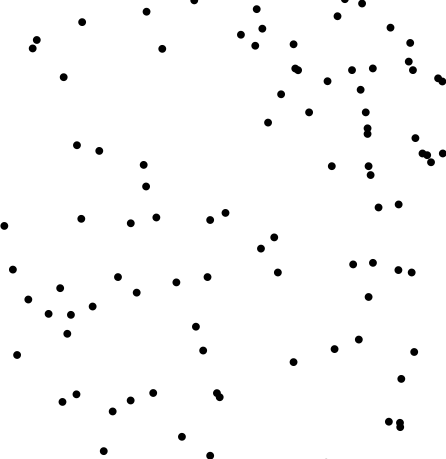

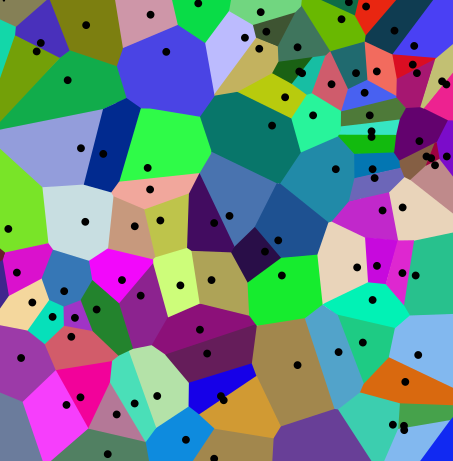

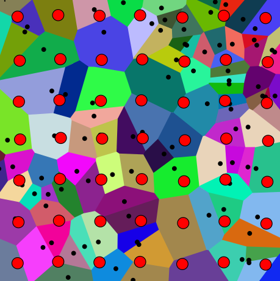

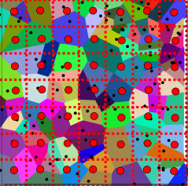

## Vicino Naturale (Natural Neighbour - NatN)

poligoni di Thiessen danno l’area di influenza.

$$Z*= Z_i$$
dove il peso è indicato da Sibson

$$Z_i(\mathbf{x})=\frac{A(\mathbf{x}_i)}{A(\mathbf{x})}$$

dove $A(x)$ è il volume della nuova cella centrata in x e A(xi) è il volume dell’intersezione tra la nuova cella centrata in x e la vecchia cella centrata in xi.

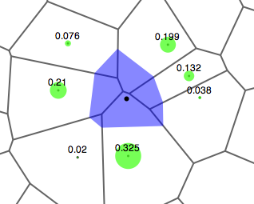

By Markluffel - Own work, CC BY-SA 3.0

- interpolatore esatto: i valori dei dati originali vengono mantenuti nei punti di riferimento.
- crea una superficie liscia priva di discontinuità.
- è interamente locale, in quanto si basa su un sottoinsieme minimo di posizioni dei dati che esclude le posizioni che, pur essendo vicine, sono più distanti di un’altra posizione in una direzione simile.
- è adattivo dal punto di vista spaziale e si adatta automaticamente alle variazioni locali della densità dei dati o della disposizione spaziale.
- privo di ipotesi statistiche (puramente deterministico).
- può essere applicato a insiemi di dati molto piccoli, poiché non è basato su dati statistici.
- privo di parametri, quindi semplice

## Inverso pesato sulla distanza (IWD)

$$Z* = F(x,y) = \sum_{i=2}^n w_i
Z_i$$
dove il peso dipende dalla distanza $h$

$$w_i = \frac {h_i^{-p}}{\displaystyle
\sum_{j=i}^n h_j^{-p}}$$

e da una potenza $p$ che va inserita dall’utente e può essere oggetto di ottimizzazione.

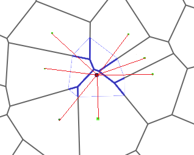

By Hassan Hadji CC-BY-SA Wiki

## Esempio IDW

```r
library(sp)
library(gstat)
data(meuse.grid)
data(meuse)
## molto importanti i passaggi sotto
coordinates(meuse) = ~x+y
coordinates(meuse.grid) = ~x+y
gridded(meuse.grid) = TRUE
###
zinc.idw = idw(zinc~1, meuse, meuse.grid)
class(zinc.idw)
spplot(zinc.idw["var1.pred"], main = "Interpolazione IDW concentrazione Zinco")
```

## Terra package

Terra package per disegnare il risultato IDW

La libreria terra riconosce l’oggetto “sp” - posso aprirlo con qualsiasi sofware GIS! Nota: non vengono specificati sistemi di riferimento.

```r
zinc.idw.terra <- terra::rast(zinc.idw)
plot(zinc.idw.terra, main="Mappa Concentrazione Zinco")
# terra::writeRaster(zinc.idw.terra, "zincIDW.tif")
```

## Esportiamo

Esportiamo raster GeoTIFF per GIS

Conoscendo l’area, vicino a Maastricht - Paesi Bassi - applichiamo un SR probabile e verifichiamo aprendo in GIS il raster salvato come GeoTIFF dopo aver assegnato il[sistema di riferimento EPSG:28992](https://epsg.io/28992)

```r
terra::crs(zinc.idw.terra) <- "EPSG:28992"
# terra::writeRaster(zinc.idw.terra, "zincIDW.tif", overwrite=T)
```

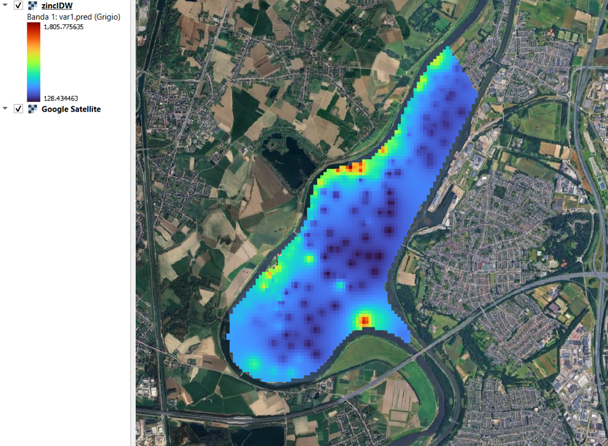

## Esercizio giorno 1

Eseguite la procedura sopra per interpolare la variabile “lead” (piombo). Salvate il GeoTIFF con il sistema di riferimento corretto nella cartella condivisa [QUI](https://drive.google.com/drive/folders/1X15ZzGnj7gIwK5kz_rhXHxVRnG3lDsaj?usp=sharing) dentro la cartella “giorno1” nominando il file cognome_nome.tif

# Giorno 2

## Contenuti

- Metodi deterministici di stima per interpolazione spaziale (IWD ed altri) - approfondimenti
- Kriging come interpolatore esatto (onora i punti): che cos’è e a cosa serve, basi teoriche
- Assunzioni su stazionarietà ed isotropia nei processi di kriging
- Variogramma sperimentale e modello di variogramma: range, sill e nugget - introduzione.

## Dataset Meuse.grid

Eseguiamo il codice alla sezione Esempio IDW e vediamo bene cosa accade e come sfruttare la libreria [terra](https://rspatial.github.io/terra/) e [stars](https://r-spatial.github.io/stars/) per facilitarci la vita. Vediamo che con un oggetto “terra” vengono disegnati vari “livelli” contenuti nell’informazione meuse.grid.

```r
plot(meuse.grid)
## convertiamo il dataset meuse
meuse.grid.terra <- terra::rast(meuse.grid)
# plot(meuse.grid.terra)
# plot(meuse.grid.terra)
```

## Conversione tra oggetti

Fondamentalmente gli interpolatori sono stimatori/predittori di valori della variabile dipendente in punti geolocalizzati. IDW se usata con formula senza covariate per stimare la concentrazione di zinco in funzione della distanza dai valori noti, ha bisogno solo dei valori con le posizioni (meuse) e di una griglia o di coordinate. Queste devono essere in oggetti di classi [Spatial*](https://edzer.github.io/sp/reference/index.html), sf o [stars](https://r-spatial.github.io/stars/).

```r
library(stars)
library(terra)
library(sf)
library(gstat)
library(sp)
### input IDW: meuse sono i dati (locations) e newdata sono le coordinate dove stimare il valore di concentrazione di zinco
zinc.idw = idw(formula=zinc~1, locations= meuse, newdata=meuse.grid)
## trasformo in oggetto "terra" funziona?
meuse.grid.terra <- terra::rast(meuse.grid)
# zinc.idw.terra = idw(formula=zinc~1, locations= meuse, newdata=meuse.grid.terra)
## trasformo in oggetto "stars" funziona?
meuse.grid.stars <- stars::st_as_stars(meuse.grid)
zinc.idw.stars = idw(formula=zinc~1, locations= meuse, newdata=meuse.grid.stars)

## trasformo in oggetto "vector" funziona?
meuse.grid.terra.vect <-  as.points(meuse.grid.terra)  # coordinate
# zinc.idw.punto.vect = idw(formula=zinc~1, locations= meuse, newdata=meuse.grid.terra.vect)
## trasformo in oggetto "sf" funziona?
meuse.grid.sf <-  sf::st_as_sf(meuse.grid.terra.vect)
zinc.idw.punto.vect = idw(formula=zinc~1, locations= meuse, newdata=meuse.grid.sf)

## funziona solo con oggetti classe Spatial, sf o stars  (vedi  manuale)
```

## Terra vs Stars

Libreria *terra* ottima per alcune applicazioni, *stars* per altre. Stars può essere usata come input per interpolatori IDW KRIGING etc… *Terra* consente di usare funzioni utili come *click* (vedi slide successiva)

## Stima il valore in una posizione

Definiamo una o più coordinate dal grafico fatto con *terra*, e la usiamo come input alla funzione *idw -* **NB** la funzione *click* usa come input un plot di un oggetto classe raster o vector di *terra*

```r
## prendiamo una coordinata dal grafico ,
## la trasformiamo in sf e la usiamo per stimare conc. zinco
## per questo però dobbiamo usare la libreria terra!
message("codice commentato da fare in autonomia in quanto richiede interazione manuale")
# plot(meuse.grid.terra[[1]])
# p <- click(meuse.grid.terra, n=1, xy=TRUE )
# print(p)
# ## devo trasformare in sf oppure in spatial*
# p_sf <- sf::st_as_sf(p, coords = c("x", "y"), crs = crs(meuse.grid.terra))
# zinc.idw.punto = idw(formula=zinc~1, locations= meuse, newdata=p_sf)
# print(zinc.idw.punto)
```

## Esercizio interattivo

Attenzione - solo elementi “terra” vengono correttamente identificati con la funzione click

```r
bubble(meuse, "zinc")
# p <- click(meuse.grid.terra, n=1, xy=TRUE)
plot(terra::vect(meuse), "zinc")
# p <- click(meuse.grid.terra, n=1, xy=TRUE)
p_sf <- sf::st_as_sf(p, coords = c("x", "y"), crs = crs(meuse.grid.terra))
zinc.idw.punto = idw(formula=zinc~1, locations= meuse, newdata=p_sf)
```

## IDW con covariate

Ma la concentrazione di zinco sembra essere correlata in qualche modo con la distanza dal fiume? Avere una covariata di facile misura può aiutare la stima, non solo con IDW ma anche con Kriging (vediamo dopo il co-kriging). Sembra ci sia una relazione, ma non lineare

```r
plot(meuse$dist, meuse$zinc)
# plot(zinc~dist, meuse)
```

Non è lineare ma possiamo trasformare i valori in log e radice quadrata

```r
plot(log(zinc)~sqrt(dist), meuse)
abline(lm(log(zinc)~sqrt(dist), meuse))
cor.zinc.dist <- cor(log(meuse$zinc),sqrt(meuse$dist))
mtext(paste("R=", round(cor.zinc.dist, 3)), side = 3)
```

Siccome questa informazione è implicitamente presente, dato che ho potenzialmente la posizione dei fiumi e dunque la distanza da essi, posso usarla, ma IDW non ha nella sua composizione spazio per un modello di trend per includere covariate, quindi va trattata separatamente.

```r
lm_fit <- lm(log(zinc) ~ sqrt(dist), data = meuse)
meuse$resid <- residuals(lm_fit)
## IDW dei residui
idw_res <- idw(resid ~ 1, meuse, meuse.grid)
## stimo dal modello lineare la concentrazione zinco
meuse.grid$trend <- predict(lm_fit, newdata = as.data.frame(meuse.grid))
## aggiungo i residui stimati
meuse.grid$logzinc_idwreg <- meuse.grid$trend + idw_res$var1.pred
meuse.grid$zinc_idwreg <- exp(meuse.grid$logzinc_idwreg)

spplot(meuse.grid["zinc_idwreg"], main = "IDW Zinco con covariata distanza")
```

## Kriging

Metodo di stima/interpolazione stocastico, non-deterministico. E’ “esatta” nel senso che onora i punti - ma anche le medie nell’area Bayesiana di maggiore probabilità (zona grigia nella figura)

$$Z(s)=m(s)+\epsilon(s)$$

- $Z(s)$ = valore della variabile al punto $s$
- $m(s)$ = **trend/mean** (parte “deterministica”, modellata da costante, covariate o regressione)
- $\varepsilon(s)$ = **componente spaziale**, parte aleatoria

Che cos’è $\varepsilon(s)$ ?

- È il **processo stocastico residuo** dopo aver tolto la media (trend).
- Ha queste proprietà statistiche:

[output not shown]

La media $m(s)$ può essere:

- **costante** → kriging ordinario
- **costante nota** → kriging semplice
- **funzione di covariate** → kriging universale / di regressione

Poiché il kriging è **regressione + interpolazione spaziale**, è possibile includere direttamente le covariate nel modello di trend.

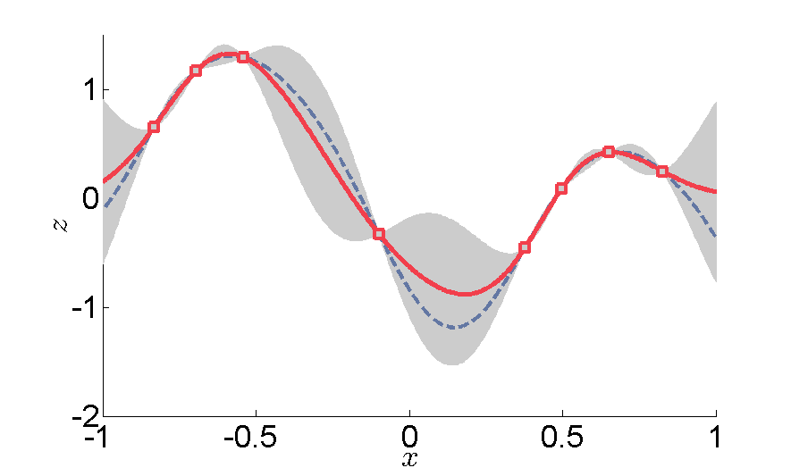

Fonte: wikipedia - I quadrati indicano la posizione dei dati. L’interpolazione con kriging, mostrata in rosso, segue le medie degli intervalli credibili a distribuzione normale mostrati in grigio. La curva tratteggiata rappresenta una spline che è liscia, ma si discosta in modo significativo dai valori attesi forniti da quelle medie.

## Stazionarietà e isotropia

L’interpolazione con kriging si basa su alcune assunzioni fondamentali riguardo alla natura dei dati spaziali. Tra queste, le più importanti sono la stazionarietà e l’isotropia.

- attenti: si presuppone un processo stocastico “stazionario”, ovvero:
  - media costante in tutta l’area analizzata
  - la varianza delle differenze dei valori analizzati dipende solo dalla **distanza** tra coppie di punti e non dalla loro posizione

I due presupposti principali affinché il kriging fornisca la migliore previsione lineare imparziale sono quelli della stazionarietà e dell’isotropia, sebbene esistano varie forme e metodi di kriging che consentono di allentare la forma più rigorosa di ciascuno di questi presupposti. Tuttavia, nella realtà, queste condizioni sono spesso violate, rendendo necessario adottare approcci più flessibili.

1. Stazionarietà “formale”: le proprietà statistiche (media e varianza) del processo spaziale rimangono costanti **in tutte le località**. La distribuzione di probabilità congiunta non varia nello spazio di studio. Di conseguenza, i parametri (come la media complessiva dei valori, l’intervallo e la soglia del variogramma*) non variano nello spazio di studio. Si presume che lo stesso modello di variogramma* sia valido in tutto lo spazio di studio. Si tratta di un’ipotesi che raramente si verifica nei dati del mondo reale.
2. Stazionarietà “debole”: si ipotizza che la media e la varianza/covarianza siano costanti nella regione di interesse

* Spoiler: il variogramma è un grafico con l’asse delle x che rappresenta la distanza tra due punti e l’asse delle y che rappresenta la varianza delle differenze tra i valori misurati in quei due punti. Solitamente si usa il SEMIvariogramma, ovvero la semivarianza, i.e. metà della media di tutte le differenze tra valori di punti che si trovano entro una certa distanza reciproca.

## Stazionarietà

La caratteristica di stazionarietà è fondamentale per molte tecniche geostatistiche

Stazionarietà di primo ordine: stazionarietà della media, ovvero un campione in due aree diverse della regione di studio hanno media uguale. Media quindi può essere costante (processo stazionario) o funzione dello spazio (trend deterministico) esempio la temperatura che cambia con la latitudine .

Stazionarietà di secondo ordine: stazionarietà della varianza, ovvero un campione in due aree diverse della regione di studio hanno varianza uguale.

## Stazionarietà - segue

Quasi sempre rappresenta una semplificazione della realtà.

La dimostrazione della stazionarietà in pratica è complesso per le seguenti ragioni:

1. **Dati limitati:** I dati geostatistici sono tipicamente sparsi e irregolarmente distribuiti, rendendo difficile valutare le proprietà statistiche sull’intera area di studio.
2. **Eterogeneità spaziale:** La maggior parte dei fenomeni naturali presenta una certa variabilità spaziale.
3. **Dipendenza dalla scala:** I pattern spaziali possono cambiare con la scala, complicando la valutazione della stazionarietà.

## Stazionarietà - esempio

Simulazione da un dataset completo temperatura, usando due transetti, vediamo effettivamente la difficoltà nel soddisfare queste condizioni:

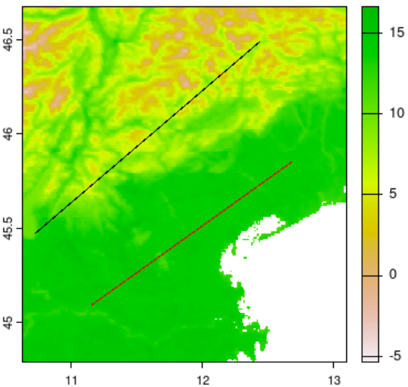

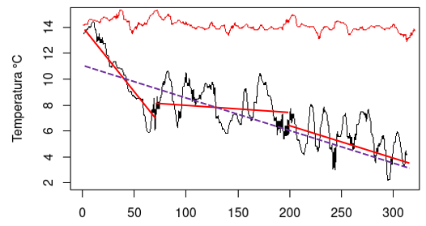

## Stazionarietà: Approcci pratici

Metodi per valutare il grado di stazionarietà:

- **Analisi esplorativa dei dati (EDA):**
  - Visualizzare i dati utilizzando istogrammi, scatter plot e mappe per identificare potenziali trend o pattern.
  - Calcolare statistiche descrittive (media, varianza) per diversi sottoinsiemi dei dati per verificare la consistenza.
- **Analisi del variogramma:**
  - Esaminare il variogramma per evidenziare la stazionarietà (ad esempio, raggiungimento di un plateau, comportamento isotropo).
  - Considerare l’adattamento di diversi modelli di variogramma per valutare la loro aderenza.

## Stazionarietà: Considerazioni

- **La stazionarietà è spesso un’approssimazione:** In pratica, spesso si assume una stazionarietà approssimativa per applicare i metodi geostatistici.
- **Stazionarietà locale:** Può essere ragionevole assumere la stazionarietà all’interno di sottoregioni più piccole.
- **Metodi non stazionari:** Se la stazionarietà è chiaramente violata, considerare l’utilizzo di metodi geostatistici non stazionari (e.g. Universal Kriging o Regression Kriging) o altre tecniche di analisi spaziale.

**Ricorda:** L’obiettivo non è dimostrare la stazionarietà senza ombra di dubbio, ma valutare la sua plausibilità e prendere decisioni informate sull’adeguatezza dei metodi geostatistici

## Test di stazionarietà

Insomma… i miei dati 2D soddisfano il presupposto di stazionarietà o no? O almeno quanto sono lontani da una perfetta stazionarietà?

NB - La stazionarietà è una decisione, non un’ipotesi (cit. M. Pyrcz); pertanto non può essere testata. I dati possono dimostrare che non è una supposizione appropriata.

La valutazione della stazionarietà dipende dalla scala. La scelta della scala deve basarsi sul problema specifico.

Per indagare/valutare la stazionarietà dei dati spaziali, in pratica la cosa migliore è usare un **variogramma o un autocorrelogramma**: - nel primo caso è un grafico che mostra come cambia il valore la covarianza a diversi lag ovvero a diverse distanze reciproche tra punti.

## Variogramma

Per ogni coppia di punti a una determinata distanza, si calcola la metà della differenza al quadrato dei loro valori. Questa quantità è chiamata **semivarianza**. Il variogramma mette nell’asse X la distanza e nell’asse Y la semivarianza calcolata in funzione della distanza (h).

Il kriging utilizza il semivariogramma, o meglio un modello matematico del semivariogramma, per calcolare le stime della superficie ai nodi della griglia. Queste stime di kriging sono le migliori stime lineari oggettive della superficie nelle posizioni specificate, a condizione che la superficie sia stazionaria e che sia stata determinata la forma corretta del semivariogramma.

$$\gamma(h) = \tfrac{1}{2} \, \mathrm{Var}\big[ Z(s) - Z(s+h) \big]$$

- $Z(s)$ = valore della variabile casuale nel punto sss.
- $h$ = vettore di spostamento (distanza e direzione).
- La varianza delle differenze cresce con hhh: punti vicini tendono a somigliarsi (piccola $\gamma(h)$ , punti lontani sono indipendenti (plateau).

## Perchè SEMIvarianza

- Serve a mantenere la relazione con la **varianza**:  
  quando $h→\infty$, la semivarianza tende alla **varianza della variabile** (non al doppio!)
- In pratica il fattore $\frac{1}{2}$ è una convenzione che garantisce che il semivariogramma sia coerente con le proprietà statistiche del processo.

## Semivarianza formula

$$\hat{\gamma}(h) = \frac{1}{2N(h)} \sum_{i=1}^{N(h)} \Big( Z(s_i) -
Z(s_i+h) \Big)^2$$

```r
lzn.vgm = variogram(log(zinc)~1, meuse)
#plot(lzn.vgm)
# prova a aggiungere argomento cloud=TRUE alla funzione variogram!
lzn.fit = fit.variogram(lzn.vgm, model = vgm(1, "Sph", 900, 1))
plot(lzn.vgm, lzn.fit)
```

- $Z(s_i)$ = valore osservato della variabile al punto $s_i$.
- $Z(s_i+h)$ = valore osservato al punto separato da distanza (o lag o intervallo di distanza solitamente nel semivario) $h$.
- $N(h)$ = numero di coppie di punti che distano circa $h$.
- La differenza al quadrato $(Z(s_i) - Z(s_i+h))^2$ misura la dissimilarità tra i due punti
- La somma fa la media di tutte le dissimilarità per le coppie a distanza $h$.

## Semivariogramma - attenzione

Ogni punto della nuvola rappresenta una coppia di punti nel set di dati, quindi il numero di punti nella nuvola aumenterà rapidamente all’aumentare del numero di punti nel set di dati. Per n punti nel set di dati, la nuvola di semivariogramma/covarianza visualizzerà

$$\frac{n*(n-1)}{2}$$

punti. Per questo motivo, non è consigliabile utilizzare set di dati con più di qualche migliaio di punti.

## Elementi del semivariogramma

- **Nugget:** Il valore iniziale del variogramma, indica la variabilità a brevissima distanza. Un nugget elevato suggerisce una componente casuale significativa.
- **Sill:** Il valore massimo a cui tende il variogramma, rappresenta la variabilità totale.
- **Portata:** La distanza alla quale il variogramma raggiunge il sill, indica la distanza oltre la quale i valori sono considerati indipendenti.

Il variogramma si dice delimitato se raggiunge un massimo tetto (sill) di varianza - vuol dire che c’è stazionarietà.

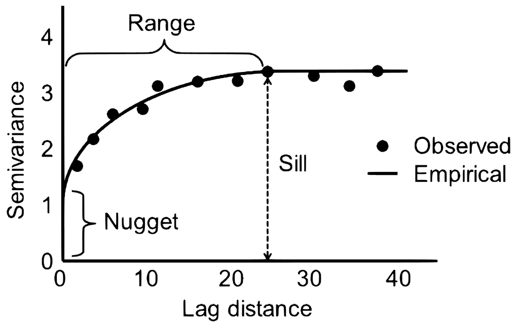

## Effetto nugget

E’ la varianza indipendente dall’autocorrelazione spaziale. Ad esempio dovuta agli errori di misura.

## cloud vs. plot

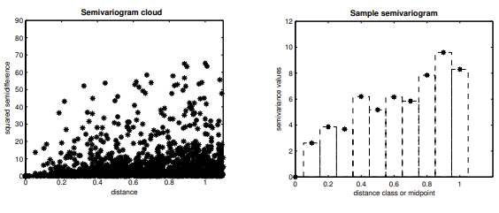

Fonte: Dr. Gaufeng Cao - University of Colorado Boulder

## Esercizio interattivo

```r
lzn.vgm = variogram(log(zinc)~1, meuse, cloud=TRUE)

plot(plot(lzn.vgm, identify = TRUE), meuse)
# plot(plot(lzn.vgm, digitize = TRUE), meuse)
```

## Modelli di variogramma

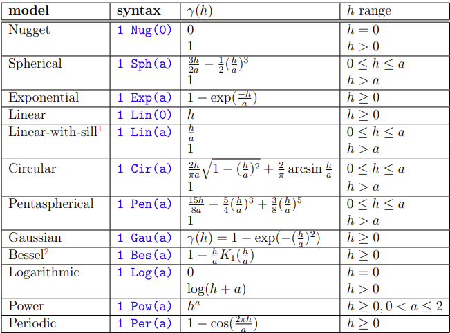

Courtesy of: GSTAT manual - https://www.gstat.org/gstat.pdf

## Modelli di variogramma (2)

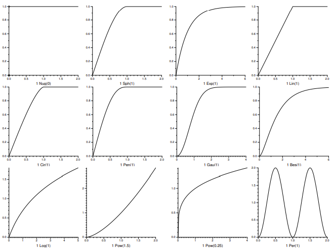

Courtesy of E.J. Pebesma - https://www.gstat.org/gstat.pdf

## Semivariogramma - esempi 1

Tipico di quota, temperatura…

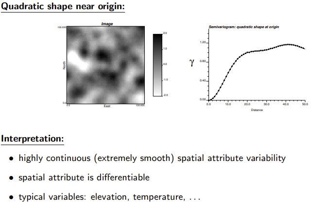

Fonte: Dr. Gaufeng Cao - University of Colorado Boulder

## Semivariogramma - esempi 2

Tipico di concentrazioni di minerali

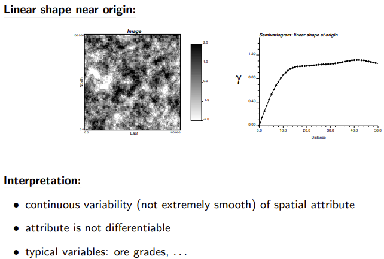

Fonte: Dr. Gaufeng Cao - University of Colorado Boulder

## Semivariogramma - esempi 3

Tipico di valori di precipitazione

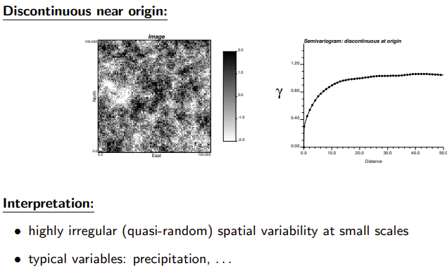

Fonte: Dr. Gaufeng Cao - University of Colorado Boulder

## Semivariogramma - esempi 4

Fenomeni che oscillano nell’area

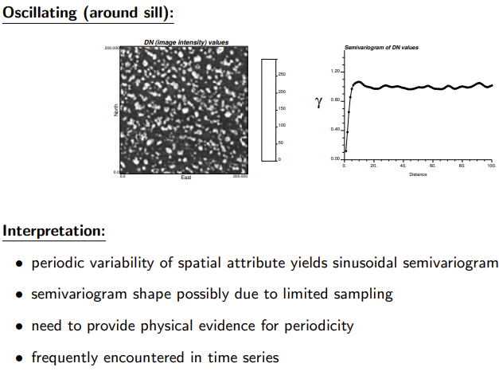

Fonte: Dr. Gaufeng Cao - University of Colorado Boulder

## Autocorrelogramma

E’ un grafico che mostra l’autocorrelazione dei valori dei dati a diversi lag (spaziali o temporali).

Si vuole studiare l’associazione tra le osservazioni della variabile analizzata in funzione di distanza e direzione. Le funzioni di covarianza, il correlogramma e il variogramma / il semivariogramma sono tutte funzioni che caratterizzano numericamente la forza di tali associazioni.

## Stazionarietà - variogramma

Il variogramma può aiutare a decidere se la variabile dipendente è stazionaria o meno.

**Forma coerente:** La forma complessiva del variogramma (ad esempio, sferica, esponenziale) deve rimanere coerente in diverse parti dell’area di studio.

**Nessuna tendenza sistematica:** Il variogramma non deve presentare tendenze chiare verso l’alto o verso il basso all’aumentare della distanza.

Vedi portale interattivo [Geospatial App](https://www.cirgeo.unipd.it/app01/GeospatialApp/)

## Isotropia

Direzionalità - si può testare fornendo un valore di *alpha* al variogramma.

```r
lzn.dir = variogram(log(zinc)~1, meuse, alpha = c(0, 45, 90, 135))
lzndir.fit = vgm(.59, "Sph", 1200, .05, anis = c(45, .4))
plot(lzn.dir, lzndir.fit, as.table = TRUE)
```

## Variabili regionalizzate

Sono grandezze il cui valore dipende dalla localizzazione ovvero dal vettore delle [X Y] di coordinate spaziali.

La teoria delle variabili regionalizzate non utilizza l’autocorrelazione, ma una proprietà correlata chiamata semivarianza per esprimere il grado di relazione tra i punti di una superficie.

La semivarianza è semplicemente la metà della varianza delle differenze tra tutti i possibili punti distanziati da una distanza costante.

La semivarianza a una distanza d = 0 dovrebbe essere pari a zero, perché non ci sono differenze tra punti che vengono confrontati con se stessi. Tuttavia, man mano che i punti vengono confrontati con punti sempre più distanti, la semivarianza aumenta. A una certa distanza, chiamata intervallo,

la semivarianza diventerà approssimativamente uguale alla varianza della superficie stessa. Si tratta della massima distanza su cui il valore di un punto della superficie è correlato al valore di un altro punto. L’intervallo definisce il massimo vicinato su cui selezionare i punti di controllo per stimare un nodo della griglia, per sfruttare la correlazione statistica tra le osservazioni. Nel caso in cui il nodo della griglia e le osservazioni siano distanziate in modo tale che tutte le distanze superino l’intervallo, il kriging produce la stessa stima della statistica classica, ovvero la media.

# Giorno 3

## Contenuti

- Variogramma sperimentale e modello di variogramma: range, sill e nugget - esercizi
- Studio variografico di una variabile georeferenziata
  - verifica stazionarietà e isotropia
- Predizione e varianza di kriging
- Esercizi con Kriging

## Studio variografico

Condizione di isotropia - verifica.

Esercizio - stima con una variabile completamente casuale

```r
#meuse$rand <- runif(nrow(meuse))

plot(variogram(log(zinc) ~ 1, meuse, alpha = c(0, 45,90, 135)))
```

## Studio variografico

Scala e densità di campioni (vedi app online per simulare campionamenti)

La distanza di **cutoff**, che è la distanza massima fino alla quale le coppie di punti vengono considerate, e il **width** è l’ampiezza dell’intervallo di distanza all’interno del quale le coppie di punti vengono mediate nei bin

```r
plot(variogram(log(zinc) ~ 1, meuse, cutoff = 2000, width = 50))
```

## Studio variografico

Intervalli personalizzati

```r
v<-variogram(log(zinc) ~ 1, meuse, boundaries = c(0, 50,  100, seq(250, 1500, 250)))
plot(v)
```

## Stimare il modello ed i parametri

Gstat utilizza il metodo dei minimi quadrati per stimare i parametri di un modello che riteniamo possa essere adatto. Se i dati non sono coerenti con il modello, potrebbe dare una non-soluzione (singular fit) e non trovare i parametri del modello.

Esercizio - fornite voi a mano un sill, nugget e range (vedi documentazione vgm e Variogramma)

```r
 # show.vgms()
# NB come mai fornisce un singular fit?
v.fit <- fit.variogram(v, vgm(1, "Sph", 10, 1))
# ?vgm
```

## Stimare il modello ed i parametri

Se c’è anisotropia (l’autocorrelazione dipende dalla direzione oltre che dalla distanza reciproca) possiamo integrarlo nel modello imponendola

```r
v.dir <- variogram(log(zinc) ~ 1, meuse, alpha = (0:3) * 45)
v.anis <- vgm(0.6, "Sph", 1600, 0.05, anis = c(45, 0.3))
plot(v.dir, v.anis)
v.fit <- fit.variogram(v.dir, v.anis)
plot(v.dir, v.fit)
```

## Anisotropia - stima direzione

```r
plot(variogram(log(zinc) ~ 1, meuse, map = TRUE, cutoff = 1000,  width = 100))
```

## Interpolazione kriging

Una volta trovato il modello adatto possiamo usarlo per l’interpolatore usando la componente stocastica - ad esempio usiamo il modello che tiene in considerazione la leggera anisotropia dei nostri dati.

```r
v.dir <- variogram(log(zinc) ~ 1, meuse, alpha = (0:3) * 45)
v.anis <- vgm(0.6, "Sph", 1600, 0.05, anis = c(45, 0.3))
v.fit <- fit.variogram(v.dir, v.anis)
lz.sk <- krige(log(zinc) ~ 1, meuse, meuse.grid, v.fit, beta = 5.9)
plot(lz.sk)
```

## Interpolazione kriging - esercizio

Provate ad applicare la stessa cosa ad una variabile differente ed ad utilizzare TERRA per creare i due plot.

```r
v.dir2 <- variogram(log(copper) ~ 1, meuse, alpha = (0:3) * 45)
v.anis <- vgm(0.6, "Sph", 1600, 0.05, anis = c(45, 0.3))
v.fit <- fit.variogram(v.dir2, v.anis)
plot(v.dir2,  v.fit)
lz.sk.cu <- krige(log(copper) ~ 1, meuse, meuse.grid, v.fit, beta = 5.9)
plot(terra::rast(lz.sk.cu), main="Rame" )
plot(terra::rast(lz.sk), main="Zinco" )
```

## Kriging: tipologie

### Geostatistica uni-(co)variata

Una variabile sola considerata o con multivariata (co-kriging)

- **Simple K** - si presuppone una media costante nota nell’area di lavoro
- **Ordinary K** - si presuppone una media costante ma ignota
- **Universal K** - si presuppone una media ignota non costante ma con un trend lineare

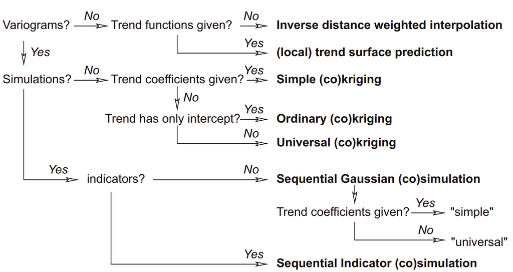

# TECNICHE DI KRIGING - Diversi Kriging

## Simple Kriging (SK)

Presuppone che la media della variabile regionalizzata sia nota. Richiede una conoscenza accurata della media. Si applica nel caso di funzioni aleatorie stazionarie con media dei residui costante e nota. Necessita di un elevato numero di dati misurati.

```r
vg <- variogram(log(zinc)~1, meuse)
fit <- fit.variogram(vg, vgm("Sph"))

sk <- krige(log(zinc)~1, meuse, meuse.grid, model=fit,
            beta=5.5)  # conosciamo la media e la forniamo
```

## Ordinary Kriging (OK)

Assume che la media della variabile regionalizzata sia sconosciuta e costante. Ampiamente utilizzato per la maggior parte delle applicazioni **dove non c’è trend**. Fornisce stime e i relativi errori Si applica nel caso di funzioni aleatorie stazionarie, ossia nel caso in cui la media dei residui sia costante in tutto il dominio di studio (stazionarietà!)

```r
vg <- variogram(log(zinc)~1, meuse)
fit <- fit.variogram(vg, vgm("Sph"))

sk <- krige(log(zinc)~1, meuse, meuse.grid, model=fit )  # niente media, viene stimata con metodo dei minimi quadrati
```

## Universal Kriging (UK)

Incorpora una superficie di tendenza (polinomiale) per modellare variazioni su larga scala. Utile quando c’è una chiara tendenza nei dati, come nel nostro caso studio.

Si applica nel caso di funzioni aleatorie non stazionarie intrinseche, ossia nel caso in cui la media dei residui non è costante e la legge di autocorrelazione presenta un trend.

La funzione aleatoria Z(x) può essere considerata in ogni punto x del dominio come la sovrapposizione di due componenti:

$$Z(s)=m(s)+\epsilon(s)$$

- $Z(s)$ = valore della variabile al punto $s$
- $m(s)$ = **trend/mean** (parte “deterministica”, modellata da costante, covariate o regressione)
- $\varepsilon(s)$ = **componente spaziale**, parte aleatoria

Se la componente residua $\varepsilon(s)$ è una funzione stazionaria e non è correlata al trend allora è possibile applicare la procedura di Kriging al residuo e quindi effettuare Universal Kriging (UK).

## Esercizio SK, OK, UK

Riassumendo; provate a cambiare alcuni parametri e visualizzare il risultato

```r
mean(log(meuse$zinc))
lz.sk <- krige(log(zinc) ~ 1, meuse, meuse.grid, v.fit, beta = 5.9)
# spplot(lz.sk)
lz.ok <- krige(log(zinc) ~ 1, meuse, meuse.grid, v.fit)
# spplot(lz.ok)

f <- log(zinc) ~ sqrt(dist)
vt <- variogram(f, meuse)
vt.fit <- fit.variogram(vt, vgm(1, "Exp", 300, 1))

lz.uk <- krige(log(zinc) ~ sqrt(dist), meuse, meuse.grid,  vt.fit)
spplot(lz.uk)
```

## Co-Kriging (CK)

Il **Co-kriging** è un’estensione del kriging ordinario che incorpora variabili aggiuntive, note come variabili secondarie o ausiliarie, per migliorare l’accuratezza della previsione della variabile primaria di interesse.

```r
# Creo oggetto gstat con due variabili
g <- gstat(NULL, "zinc", log(zinc)~1, meuse)
g <- gstat(g, "cadmium", log(cadmium)~1, meuse)

# Variogrammi e cross-variogramma
vg <- variogram(g)

# Fit LMC con un modello sferico (va adattato manualmente)
model <- vgm(psill=1, model="Sph", range=900, nugget=0.05)
fit <- fit.lmc(vg, g, model)
```

## Come funziona CK:

- **Variabili multiple:** Considera più variabili contemporaneamente. **Correlazione incrociata:** Utilizza la correlazione incrociata tra le variabili primarie e secondarie.
- Previsione migliorata: Incorporando le informazioni provenienti da variabili correlate, il co-kriging può spesso fornire previsioni più accurate rispetto al kriging ordinario.

## Differenze chiave rispetto al Kriging ordinario:

**Dati:** Il kriging ordinario utilizza una sola variabile, mentre il co-kriging utilizza più variabili.

**Complessità del modello:** Il co-kriging comporta la modellazione delle correlazioni incrociate tra le variabili, rendendolo più complesso del kriging ordinario.

**Accuratezza della previsione:** Il co-kriging spesso porta a un miglioramento dell’accuratezza della previsione grazie alle informazioni aggiuntive fornite dalle variabili secondarie.

## Vantaggi del Co-Kriging:

- **Miglioramento dell’accuratezza:** Come già detto, può migliorare significativamente l’accuratezza della previsione.
- **Uso efficiente dei dati:** Sfrutta le informazioni provenienti da più variabili, sfruttando al massimo i dati disponibili.
- Gestire i dati mancanti: può essere utilizzato per stimare i valori mancanti in una variabile sulla base dei valori di altre variabili.

## Applicazioni del Co-Kriging:

- **Scienze ambientali:** Previsione delle proprietà del suolo, dei livelli di inquinamento atmosferico, ecc. **Idrologia:** Stima dei livelli delle acque sotterranee, delle precipitazioni, ecc. **Geostatistica:** Previsione dei gradi dei minerali, delle riserve minerarie, ecc.

**In sostanza, il co-kriging è uno strumento prezioso quando si hanno più variabili correlate e si vuole migliorare l’accuratezza delle proprie previsioni.**

## External drift Kriging (EDK)

**L’EDK (External Drift Kriging)** è una variante dell’Universal Kriging in cui la componente di tendenza o deriva è determinata da variabili esterne anziché dalle sole coordinate spaziali.

```r
edk <- krige(log(zinc)~dist, meuse, meuse.grid, model=fit)
```

## Come funziona EDK:

- **Variabili esterne:** si tratta di variabili ausiliarie che influenzano la variabile dipendente. Possono essere qualsiasi cosa, dall’altitudine all’uso del suolo, dal tipo di terreno a qualsiasi altro fattore rilevante.
- Un modello di regressione viene utilizzato per modellare la relazione tra la variabile dipendente e le variabili esterne.
- I residui di questo modello di regressione rappresentano la componente spazialmente correlata dei dati. **Kriging:** Il Kriging ordinario viene quindi applicato a questi residui per interpolarli.
- La previsione finale in una località non campionata è la somma del valore previsto dal modello di regressione e del residuo previsto dal kriging.

## Differenze chiave rispetto al Kriging universale:

- **Definizione della deriva:** Il kriging universale utilizza funzioni polinomiali delle coordinate spaziali per modellare la deriva, mentre l’EDK utilizza variabili esterne.
- **Flessibilità:** EDK offre una maggiore flessibilità in quanto può incorporare vari tipi di variabili esterne, migliorando potenzialmente l’accuratezza della previsione.

## Vantaggi dell’EDK:

- **Migliore accuratezza:** Incorporando variabili esterne rilevanti, EDK può spesso fornire previsioni più accurate rispetto a Universal Kriging.
- **Migliore comprensione:** L’EDK aiuta a comprendere l’influenza dei fattori esterni sulla variabile di interesse.
- **Versatilità:** Può essere applicato a un’ampia gamma di dati e problemi spaziali.

**In sostanza, l’External Drift Kriging è un potente strumento di previsione spaziale quando esiste una chiara relazione tra la variabile di interesse e altri fattori esterni.**

## Regression Kriging (RK)

Il **Regression Kriging** è una tecnica di interpolazione spaziale che combina i punti di forza della regressione e del kriging. È essenzialmente un metodo ibrido.

```r
lm_fit <- lm(log(zinc)~dist, data=meuse@data)
meuse$resid <- residuals(lm_fit)

vg_res <- variogram(resid~1, meuse)
fit_res <- fit.variogram(vg_res, vgm("Sph"))

rk <- krige(resid~1, meuse, meuse.grid, model=fit_res)
rk$pred <- rk$var1.pred + predict(lm_fit, meuse.grid@data)
```

## Come funziona RK:

1. Un modello di regressione viene costruito per spiegare la variazione della variabile target utilizzando variabili ausiliarie (covariate).
2. I residui del modello di regressione rappresentano la parte non spiegata della variazione.
3. I residui vengono interpolati con tecniche di kriging (come il Kriging ordinario) per catturare l’autocorrelazione spaziale.
4. La previsione finale è la somma del valore previsto dal modello di regressione e del residuo previsto dal kriging.

## Differenze chiave RK rispetto ad altri metodi:

- **Combina regressione e kriging:** Questo approccio ibrido sfrutta i punti di forza di entrambi i metodi.
- **Incorpora variabili ausiliarie:** Il kriging di regressione utilizza esplicitamente variabili ausiliarie per migliorare l’accuratezza della previsione.
- Il modello di regressione cattura le tendenze su larga scala, mentre il kriging gestisce l’autocorrelazione spaziale su piccola scala.

## Vantaggi di RK:

- **Migliore accuratezza:** Spesso fornisce previsioni più accurate rispetto al semplice kriging o alla sola regressione.
- **Flessibilità:** Può adattarsi a vari tipi di modelli di regressione e tecniche di kriging.
- Migliore comprensione:** Aiuta a capire l’influenza delle variabili ausiliarie sulla variabile target.

## Applicazioni del RK:

- **Scienze ambientali:** Previsione dell’inquinamento atmosferico, delle proprietà del suolo, ecc.
- **Idrologia:** Stima dei livelli delle acque sotterranee, delle precipitazioni, ecc. **Agricoltura:** Previsione della resa dei raccolti, dell’umidità del suolo, ecc.

**In sostanza, il Kriging di regressione è uno strumento potente quando esistono tendenze o modelli significativi nei dati che possono essere spiegati da variabili ausiliarie e quando esiste anche un’autocorrelazione spaziale nei residui.**

## Indicator Kriging (IK)

Tratta i dati come categorici (ad esempio, sopra o sotto una soglia). Utilizzato per la mappatura probabilistica e la valutazione del rischio.

```r
meuse$ind <- ifelse(meuse$zinc > 1000, 1, 0)

vg_ind <- variogram(ind~1, meuse)
fit_ind <- fit.variogram(vg_ind, vgm("Sph"))

ik <- krige(ind~1, meuse, meuse.grid, model=fit_ind)

## oppure (da bivand et al. )
# Definizione della formula indicatore
ind.f <- I(zinc < 500) ~ 1
# Stima del variogramma
ind.fit <- fit.variogram(variogram(ind.f, meuse), vgm(1, "Sph", 800, 1))
# Kriging per indicatori
ind.kr <- krige(ind.f, meuse, meuse.grid, model = ind.fit)
```

## Alcune criticità

I risultati possono risultare carenti quando:

- La geostatistica viene spesso applicata con pochi dati a disposizione.
- Raramente viene indicato il modello di stima e di interpolazione utilizzato.
- Spesso non vengono indicati i punti utilizzati per l’interpolazione e/o i valori che la variabile assume in tali punti, né il dominio di studio.
- A volte vengono utilizzate condizioni al contorno nell’area (punti fittizi) che non rispecchiano dati reali misurati.
- Raramente vengono applicati più modelli di stima allo stesso set di dati ed effettuato il confronto fra le varianze di stima.
- Quando vengono utilizzati modelli statistici (kriging), non viene riportata la determinazione del variogramma sperimentale e del variogramma modello utilizzato, né viene prodotta la mappa delle incertezze.

**non limitarsi solo a fornire delle “mappe”, ma indicare tutte le valutazioni che le hanno prodotte oltre all’incertezza dei risultati.**

## Esercizio finale

Esegui un’interpolazione con IDW (già fatta nel giorno 1 vedi [Esercizio finale giorno 1]) ed una usando il kriging UK usando sqrt(dist) come covariata - consegnare il raster usando TERRA per salvare come raster GeoTIFF, includendo il sistema di riferimento corretto (vedi [Esportiamo raster GeoTIFF per GIS] ), come [Esercizio finale giorno 1]

## Prossimo corso…

- applicazioni dei vari kriging su dataset differente e più complessi
- co-variogrammi e co-kriging per appaiare più covariate
- metodi di validazioni rigorose
- …